# Reproducible Research: Peer Assessment 1

## Loading and preprocessing the data

### Part 1 - Mean and Median of the Total number of steps taken per day.

#### Step 1 - Read the data.

```r
act_data <- read.csv("activity.csv", header = T)
```

#### Step 2 - Group the data and summarize

Group the data by date and calculate sum of steps for each day using group_by and summarize functions of dplyr package

```r
library(dplyr)
daily <- act_data %>%
          group_by(date) %>%
           summarise(total_steps = sum(steps))

per_day <- daily$total_steps
```

#### Step 3 - Histogram of Total number of steps taken

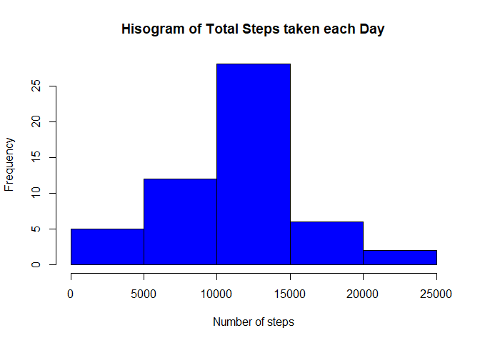

```r
hist(per_day,
     main = "Hisogram of Total Steps taken each Day",
     xlab = "Number of steps",
     col = "blue")
```

```r
mean_steps <- mean(daily$total_steps, na.rm = T)
median_steps <- median(daily$total_steps, na.rm = T)
```

## What is the average daily activity pattern?

#### Step 1 - Average daily activity Pattern

This is to see the pattern of activity in different 5 minute intervals of time.

First we group the data by interval and then calculate mean of each group using summarise function.

```r
act_pat <- act_data %>%
            group_by(interval) %>%
            summarise(avg_steps = mean(steps, na.rm = T))
```

#### Step 2 - Time series plot of 5- minute interval

Here’s a time series plot of the 5-minute interval (x-axis) and the average number of steps taken, averaged across all days (y-axis)

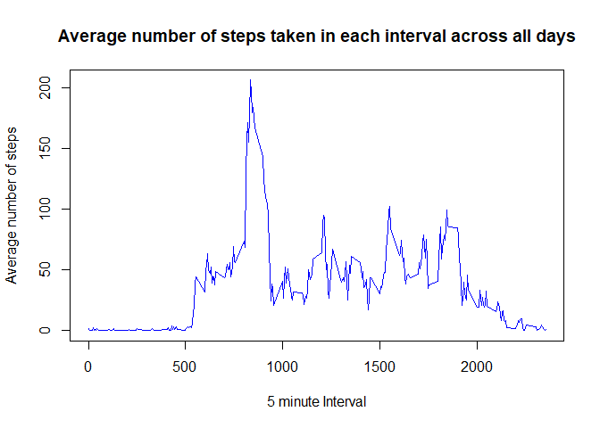

```r
plot(act_pat, type = "l",
     main = "Average number of steps taken in each interval across all days",
     xlab = "5 minute Interval",
     ylab = "Average number of steps",
     col = "blue")
```

#### Step 3 - Interval with maximum mumber of steps

Calcualte the interval with maximum number of steps taken.

```r
max_int <- act_pat[which.max(act_pat$avg_steps),1]
```

Interval with maximum number of steps is 835.

## Imputing missing values

#### Step 1 - Calculate the number of missing values

```r
missing_values <- sum(is.na(act_data$steps))
```

The number of missing values is 2304

#### Step 2 - Remove the missing values, calculate daily activity and set the value of activity data to new object.

```r
activity_rm <- act_data[complete.cases(act_data$steps),]
```

Calculate daily activity.

```r
daily_act <- tapply(activity_rm$steps, activity_rm$interval, mean)
```

Set the value of original activity data to an object called new_act

```r
new_act <- act_data
```

#### Step 3 - Impute the missing values in the new object.

```r
new_act[which(is.na(new_act$steps)),1]<-
      daily_act[as.character(new_act[which(is.na(new_act$steps)),3])]
```

#### Step 4 - Calculate new daily activity with no missing values

```r
perday_new <- new_act %>%
              group_by(date) %>%
              summarise(total_steps = sum(steps))
```

#### Step 5 - Plot the data with and without missing values.

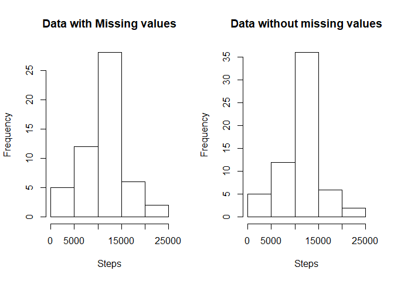

```r
par(mfrow = c(1,2))

hist(per_day,
     main = "Data with Missing values",
     xlab = "Steps")

hist(perday_new$total_steps,
     main = "Data without missing values",
     xlab = "Steps")
```

#### Step 6 - Calculate mean and median of using imputed data

```r
mean_perdayNew <- mean(perday_new$total_steps)
median_perdayNew <- median(perday_new$total_steps)
```

## Are there differences in activity patterns between weekdays and weekends?

#### Step 1- Setting the day of the week to each observation

Add a variable called day that converts the date to the corresponding day of the week

```r
new_act$day <- weekdays(as.Date(new_act$date))
```

Add another factor variable called fday, which has two factors Weekend and Weekday

```r
new_act$fday <- as.factor(c("Weekend", "Weekday"))
```

Set the values Weekend to Sunday and Saturday and Weekday to all others

```r
new_act[new_act$day == "Sunday" | new_act$day == "Saturday",5] <- factor("Weekend")
new_act[!(new_act$day == "Sunday" | new_act$day == "Saturday"),5] <- factor("Weekday")
```

#### Step 2 - Seperate the dataframe on Weekdays and Weekend

```r
new_act_we <- new_act[new_act$fday == "Weekend",]
new_act_wd <- new_act[new_act$fday == "Weekday",]
```

#### Step 3 - Summarize the data

```r
weekend_act <- tapply(new_act_we$steps, new_act_we$interval, mean)
weekday_act <- tapply(new_act_wd$steps, new_act_wd$interval, mean)
```

#### Step 4 - Plot the Weekend and Weekday data adjacently.

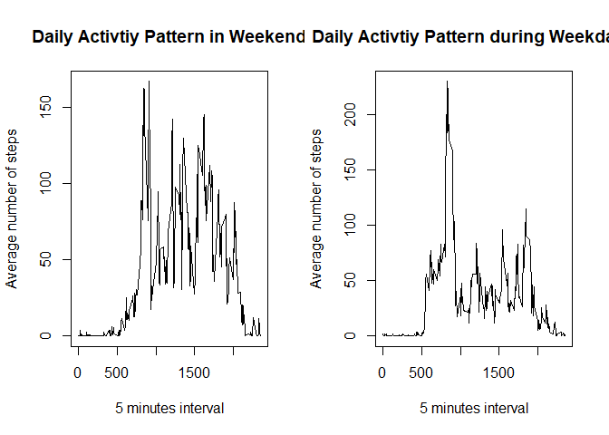

```r
par(mfrow = c(1,2))

plot(y = weekend_act, x = names(weekend_act), type = "l", xlab = "5 minutes interval",
     main = "Daily Activtiy Pattern in Weekend",
     ylab = "Average number of steps")
plot(y = weekday_act, x = names(weekday_act), type = "l", xlab = "5 minutes interval",
     main = "Daily Activtiy Pattern during Weekdays",
     ylab = "Average number of steps")
```